# Behavioural tests

### 5.3 Plots

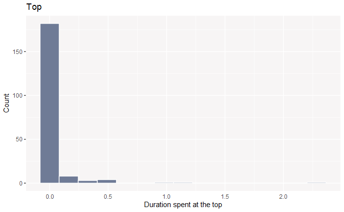

```r
ggplot(data = top_output, aes(duration_top)) +
    geom_histogram(aes(),
                   bins = 15,
                   fill="#6f7b96",
                   colour = "white") +
    labs(x="Duration spent at the top", y="Count") +
    theme(axis.ticks.x = element_blank(),
          panel.background = element_rect(fill = "#f7f5f5")) + ggtitle("Top")
```

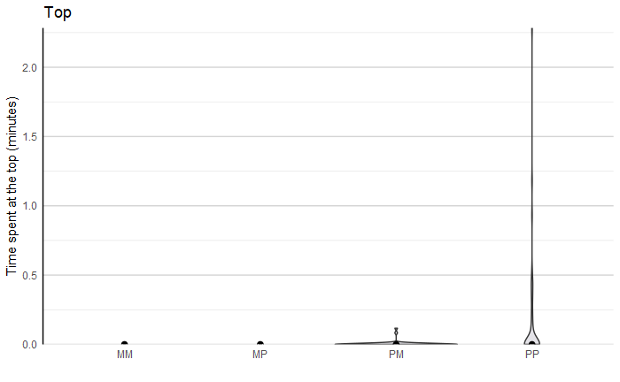

```r
 # Violin plots for differences between the 8 ponds within a week

    ggplot(data = top_output, aes(x = Treatment_seq, y = duration_top)) +
      geom_violin(fill = "#e4e3e8") +
      #geom_boxplot(fill = "white", width = 0.1, outlier.alpha = 0.3,) +
      theme(panel.grid.major.y = element_line(colour = "#d4d4d4"),
            panel.grid.major.x = element_blank(),
            panel.grid.minor = element_line(colour = "#e6e6e6"),
            axis.ticks.y = element_blank(),
            axis.ticks.x = element_blank(),
            panel.background = element_blank(),
            axis.line.y = element_line(color = "black")) +
      labs(y = "Time spent at the top (minutes)", x =" ") +
      scale_y_continuous(expand = c(0, 0))  + ggtitle("Top") +
      stat_summary(fun = median, geom="point", size=2, color="black")
```

```r
NA
```

## 5. Shoaling index

I want to obtain the proportion of time that each individual spends with at least one conspecific, as a proxy for shoaling/social tendency. To do so, I first wish to know how many times each individual was read at the same time than at least another fish at a certain antenna (hereafter named *accompanied reads*, or *AR*). Then, I simply divide this number by the total number of reads.

To reach this goal, I write two functions:

### 5.1 *shoaling.index.pond* Function

This function has, as an:

- Input n°1 = A clean data frame containing all the reads (for a certain test) at one pond.
- Input n°2 = The variables of all the fish present in this pond.
- Output = A data frame containing all the individuals (and not only the ones that were read) of this pond, and for each of them, their number of accompanied reads, and their total number of reads.

```r
shoaling.index.pond <- function(clean_df_pond, df_variables){

  #clean_df_pond <- subset(bottom_clean_df, Pond == 1)
  #df_variables <- subset(bottom_variables, Pond == 1)

  # If an individual has been read at the top in this pond
  if (nrow(clean_df_pond != 0)){

  # I split my data frame into a list of dataframes (one object per individual)
  clean_df_2 <- split(clean_df_pond, f = clean_df_pond$antenna)

  # I define a list
  accompanied_reads <- list()

  # For each antenna...
  for (i in 1:length(clean_df_2)){
    # If an individual has been read in this antenna
    if (nrow(clean_df_2[[i]] != 0)){

    # I subset all the time points for which more than 1 individuals were read at one antenna
    accompanied_reads[[i]] <-  clean_df_2[[i]] %>% group_by(time) %>% filter(n() > 1)

    # I count the number of accompanied reads per individual
    accompanied_reads[[i]] <- accompanied_reads[[i]] %>% group_by(id) %>% add_tally()
    # I remove duplicated rows
    accompanied_reads[[i]] <- accompanied_reads[[i]][!duplicated(accompanied_reads[[i]][,c('id')]),]
    }
    }


  # I bind the rows of the list of dataframes
  accompanied_reads <- bind_rows(accompanied_reads)

  # I keep the total number of accompanied reads in all antennas
  accompanied_reads <- accompanied_reads %>%
    group_by(id) %>%
    mutate(tot_acc_reads = sum(n))



  # I remove the 'n' column, useless now
  accompanied_reads <- accompanied_reads[,- c(7)]
  # I remove duplicated rows
  accompanied_reads <- accompanied_reads[!duplicated(accompanied_reads[,c('id')]),]

  # Now, I want to take into account the total number of reads of each individual as well
  clean_df_pond <- clean_df_pond %>% group_by(id) %>% add_tally()
  clean_df_pond <- clean_df_pond[!duplicated(clean_df_pond[,c('id')]),]
  clean_df_pond <- merge(df_variables, clean_df_pond[c("id", "n")], by = "id", all = T)
  clean_df_pond[is.na(clean_df_pond)] <- 0

  # I add them to the data frame with the accompanied reads
  accompanied_reads <- merge(clean_df_pond[c("id", "Pond", "time_of_day", "Treatment_seq", "n")],
                             accompanied_reads[c("id", "tot_acc_reads")], by = "id", all = T)
  names(accompanied_reads)[5] <- "tot_reads"
  accompanied_reads[is.na(accompanied_reads)] <- 0
  return(accompanied_reads)

  } # end of the first 'if'

} # end of function
```

### 5.2 *shoaling.index.* Function

This function is using the function just above, but for an entire dataset, and not just one pond.

- Input n°1 = A clean data frame containing all the reads (for a certain test) at *all* pond.
- Input n°2 = The variables of *all the fish*.
- Output = A data frame containing all the individuals (and not only the ones that were read), and for each of them, their number of accompanied reads, their total number of reads, and the accompanied reads divided by the total reads, (*i.e.* shoaling index).

```r
  # Example data frames
  #clean_df <- bottom_clean_df
  #variables_df <- bottom_variables


shoaling.index <- function(clean_df, variables_df){
# I define my objects
  variables_per_pond <- list()
  clean_df_list <- list()
  list <- list()

  # For each Pond
  for (i in 1:8){
    # I split my data frame per pond
    clean_df_list[[i]] <- subset(clean_df, Pond == i)
    # I split my variable df by pond
    variables_per_pond[[i]] <- subset(variables_df, Pond == i)

    # If fish were read at this pond...
    if (nrow(clean_df_list[[i]]) != 0){

    # ... Then apply the function defined above, and obtain the reads
    # and accompanied reads per individual.
    list[[i]] <- shoaling.index.pond(clean_df_list[[i]], variables_per_pond[[i]])
    }

    # If however no fish was read in this pond
    if (nrow(clean_df_list[[i]]) == 0){
    # Then my data frame has 0s for total number of reads and accompanied reads
    list[[i]] <- data.frame(variables_per_pond[[i]], tot_reads = 0, tot_acc_reads = 0)
    }
  }

  # I bind the rows of my list, and obtain a long data frame
  Shoaling_index <- bind_rows(list)
  # I create my Shoaling index by dividing acc. reads by tot. reads.
  Shoaling_index$shoaling <- Shoaling_index$tot_acc_reads/Shoaling_index$tot_reads
  # My NAs = 0
  Shoaling_index[is.na(Shoaling_index)] <- 0



  return(Shoaling_index)
  }
```

I apply the function to the cleaned data sets, and assemble them as ggplot-friendly vertical table.

```r
  shoaling_EB <- shoaling.index(EB_clean_df, EB_variables)
  shoaling_EB$test <- "EB"

  shoaling_bottom <- shoaling.index(bottom_clean_df, bottom_variables)
  shoaling_bottom$test <- "bottom"

  shoaling_top <- shoaling.index(top_clean_df, top_variables)
  shoaling_top$test <- "top"

  shoaling_shelters <- shoaling.index(shelter_clean_df, shelter_variables)
  shoaling_shelters$test <- "shelter"

  shoaling_vertical <- rbind(shoaling_EB, shoaling_bottom,
                      shoaling_top, shoaling_shelters)
```

Then, I spread sum the reads (accompanied and total) together using *dplyr*, to give a global shoaling index (*i.e.* proportion of time spent with at least one conspecific, across tests).

```r
  # I depart from the shoaling_vertical df
  shoaling_output <- shoaling_vertical %>%
  # I group by individuals
  group_by(id) %>%
  # I create a new column with the sum of total and acc reads
  mutate(tot_reads = sum(tot_reads), tot_acc_reads = sum(tot_acc_reads)) %>%
  # I remove repeats
  distinct(id, .keep_all = TRUE)

  # I make the shoaling index columns based on the number of reads across tests
  shoaling_output$shoaling <- shoaling_output$tot_acc_reads/shoaling_output$tot_reads
```

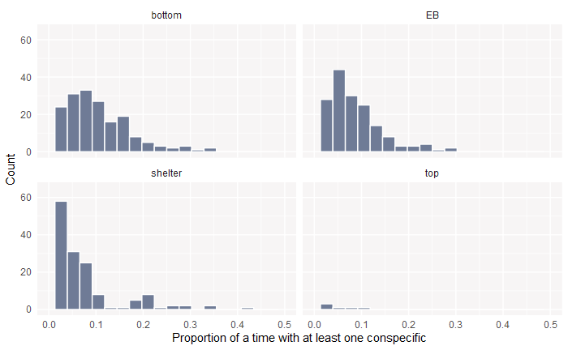

```r
ggplot(data = shoaling_vertical, aes(shoaling)) +
    geom_histogram(aes(),
                   bins = 20,
                   fill="#6f7b96",
                   colour = "white") +
    labs(x="Proportion of a time with at least one conspecific", y="Count") +
    theme(axis.ticks.x = element_blank(),
          axis.ticks.y = element_blank(),
          panel.background = element_rect(fill = "#f7f5f5"),
          strip.background = element_rect(colour="white", fill="white")) +
  xlim(c(0,0.5)) +
  ylim(c(0,65)) + facet_wrap(~ test)
```

```r
NA
NA
NA
NA
```

I plot the distribution of shoaling index across tests:

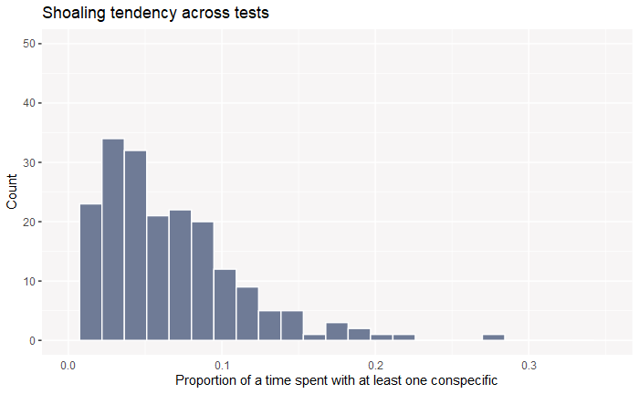

```r
ggplot(data = shoaling_output, aes(shoaling)) +
    geom_histogram(aes(),
                   bins = 25,
                   fill="#6f7b96",
                   colour = "white") +
    labs(x="Proportion of a time spent with at least one conspecific", y="Count") +
    theme(axis.ticks.x = element_blank(),
          panel.background = element_rect(fill = "#f7f5f5")) +
  xlim(c(0,0.35)) +
  ylim(c(0,50)) + ggtitle("Shoaling tendency across tests")
```

### 5.3 Plots

[figure not shown]

```r
 # Violin plots for differences between the 8 ponds within a week
ggplot(data = shoaling_output, aes(x = Treatment_seq, y = shoaling, fill = time_of_day)) +
      geom_violin(position = position_dodge(width = 0.5)) +

      #geom_boxplot(width=.1, outlier.alpha = 0.1,
      #             position = position_dodge(width = 0.4), colour = "black") +

      scale_fill_brewer(palette="Blues") +

      # theme_bw() +
      theme(panel.grid.major.y = element_line(colour = "#d4d4d4"),
            panel.grid.major.x = element_blank(),
            panel.grid.minor = element_line(colour = "#e6e6e6"),
            axis.ticks.y = element_blank(),
            axis.ticks.x = element_blank(),
            panel.background = element_blank(),
            axis.line.y = element_line(color = "black")) +
      labs(y = "Time spent hidin (minutes)", x =" ") +
      scale_y_continuous(expand = c(0, 0), limits = c(0,NA)) + ggtitle("Hiding") +
      stat_summary(fun = median, geom="point", size=2, color="black", position = position_dodge(width = 0.5))
```

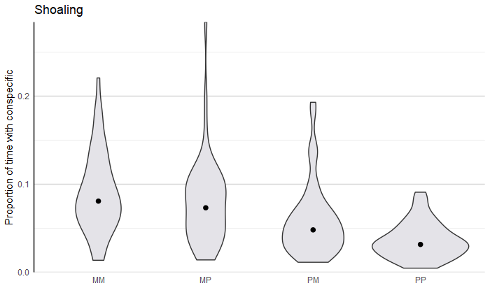

```r
ggplot(data = shoaling_output, aes(x = Treatment_seq, y = shoaling)) +
      geom_violin(fill = "#e4e3e8") +
      #geom_boxplot(fill = "white", width = 0.1, outlier.alpha = 0.3,) +
      theme(panel.grid.major.y = element_line(colour = "#d4d4d4"),
            panel.grid.major.x = element_blank(),
            panel.grid.minor = element_line(colour = "#e6e6e6"),
            axis.ticks.y = element_blank(),
            axis.ticks.x = element_blank(),
            panel.background = element_blank(),
            axis.line.y = element_line(color = "black")) +
      labs(y = "Proportion of time with conspecific", x =" ") +
      scale_y_continuous(expand = c(0, 0), limits = c(0,NA)) + ggtitle("Shoaling") +
      stat_summary(fun = median, geom="point", size=2, color="black")
```

```r
NA
NA
```

## 6. Summary of the week

I can first look at the individuals that were never read during the whole week. These individuals could have died, lost their tag, or their tags might be les/non functional.

```r
# I obtain the name id of the fish that were read in none of the tests
  week1_miss_ind <- Reduce(intersect, list(EB_missing$missing_id,
                       bottom_missing$missing_id,
                       shelter_missing$missing_id,
                       top_missing$missing_id))

# I make it a one column data frame
  week1_miss_ind <- data.frame(id = week1_miss_ind)
# I assign the individuals to their pond
  week1_miss_ind <- merge(week1_miss_ind, list_fish[,c("id", "Pond")], by = "id", all = F)
  print(week1_miss_ind)
```

| id | Pond |
| --- | --- |
| 0007D4C2EF | 1 |
| 0007EA0E1C | 1 |

```r
week1_df <- tibble(EB_output[c("id", "Treatment_seq", "Pond", "latency_entrance")],
                    bottom_output[c("Dist")],
                    shelter_output[c("duration_shelter")],
                    top_output[c("duration_top")],
                    shoaling_output[c("shoaling")])
```

[figure not shown]